# Informe comisión de vehículos IER

```
[1] "Actualizado: 2024-04-16"
```

La información presentada en este documento es extraída del archivo **cuentas_y_plazos_vehiculos_IER** alojado en el repositorio de Drive [“3.vehículos IER”](https://drive.google.com/drive/folders/1dkgFBlNmLiKsD2cTdqTORJRr-4GCgmgT?usp=share_link). Este `html` fue producido en [Quarto](https://quarto.org), para generarlo debe contar con `R 3.3.0+`, `RStudio 2023.03.0+`, el archivo fuente (informe_comision_vehiculos.qmd) y la actualización local de la base de datos ([cuentas_y_plazos_vehiculos_IER.xlsx](https://quarto.org)).

El informe contiene:

1. **Finanzas generales.** Dinero disponible en cuenta y caja chica, e información necesaria para estimar el costo del alquiler. También incluye resumen del gastos mensual por vehículo y acciones de mantenimiento.
2. **Uso.** Resumen del número de días de alquiler durante el presente y pasado año.
3. **Fechas límite.** Incluye vencimiento de botiquín, extintor, VTV y pólizas de seguro. También se contempla fecha estimada para mantenimiento general de cada vehículo dado (e.g. alineado y balanceo, cambio de aceite, pastillas de freno, etc.).
4. **Nómina actual de conductores.** Corresponde a aquellas personas habilitadas por el IER y con cédula azul vigente. También incluye información de la categoría del carnet de manejo y vencimiento.

# 1. Finanzas generales

### Monto de alquiler.

El alquiler de los vehículos se estima a partir del valor del tanque lleno de `nafta super` para la Kangoo (55 L) (precio por litro YPF Buenos Aires).

El valor mensual del combustible se consulta en el siguiente enlace https://surtidores.com.ar/precios/.

### Dinero disponible

```
Saldo en cuenta= 235036.05$
```

```
Saldo en caja chica= 930$
```

```
Total= 235966.05$
```

### Gastos

```
En lo que va corrido del año, 2024-04-16, no se han reportado gastos.
```

```
En los dos años anteriores tenemos:
```

| auto | year | gasto |
| --- | --- | --- |
| s10 | 2022 | 0 |
| kangoo | 2022 | 90155 |
| kangoo | 2023 | 90190 |
| s10 | 2023 | 185700 |

### Acciones de mantenimiento

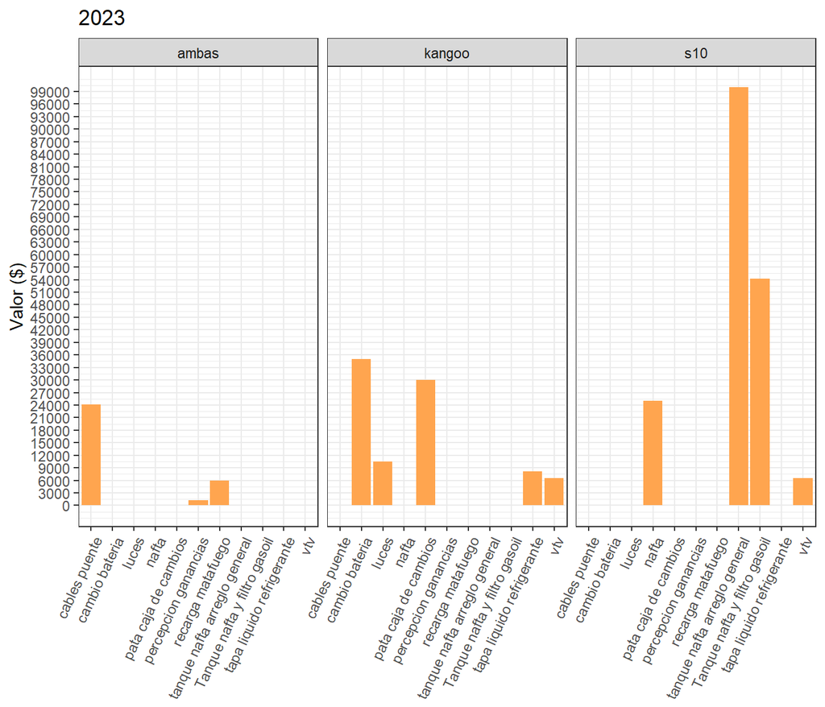

- Nota 1. Las columnas solo aplican para el auto en el que se realizó el gasto.
- Nota 2. Si una categoría de gasto no posee columna para ambos autos, indica que en el archivo **cuentas_y_plazos_vehiculos_IER** esta celda es un `NA` en la columna `monto`.

# 2. Uso

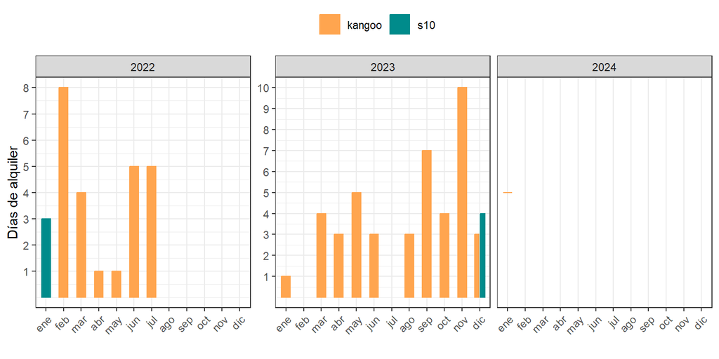

Número de días de alquiler durante el presente y los dos años anteriores.

# 3. Fechas límite

### Vencimientos

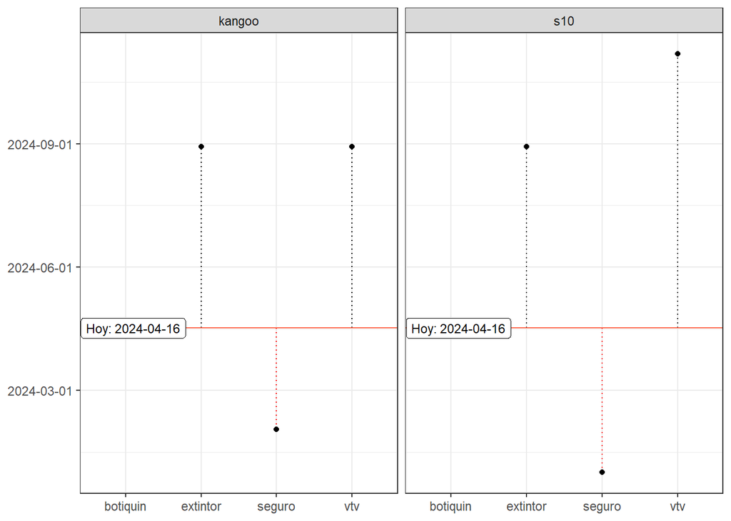

### Service

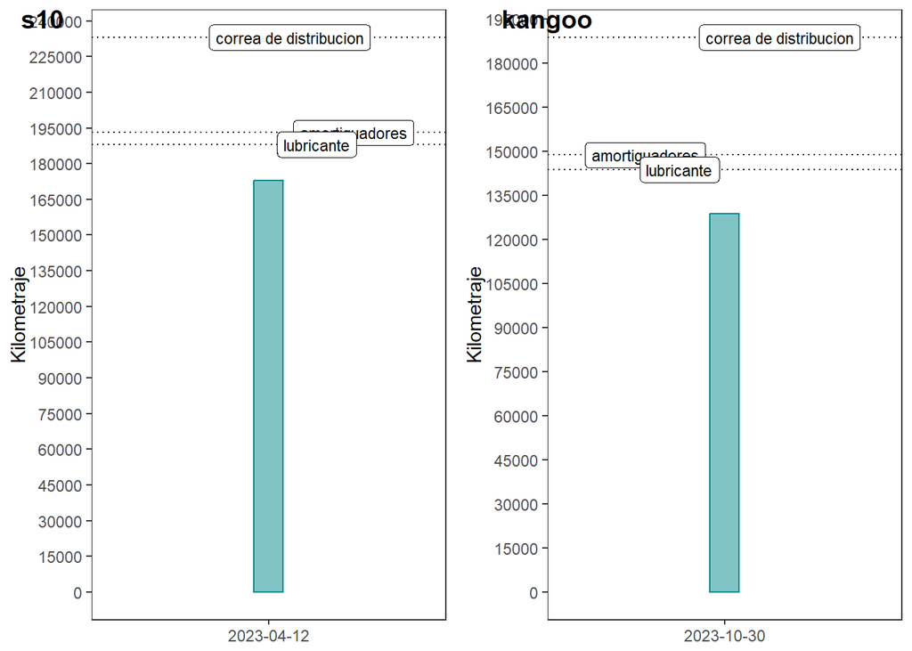

# 4. Nómina actual de conductores

| Nombre | cargo | tarjeta_azul | categoria_licencia |
| --- | --- | --- | --- |
| Adriana Carolina Cuezzo | CPA | Si | B1 |
| Agostina Ferro Franco Sosa | becario doctoral | Si | B1 |
| Ana Carolina Monmany | Investigadora | Si | B1 |
| Andres Ramirez | becario doctoral | Si | B1 |
| Leandro Macchi | Investigadora | Si | B2 |
| Maia Carisa Plaza Behr | becario doctoral | Si | B1 |
| María Josefina Zelaya | becario doctoral | Si | B1 |
| Mariano Andrés Ordano | Investigador | Si | B1 |
| Pedro Gerardo Blendinger | Investigador | Si | B1 |
| Silvio Eugenio Castillo | becario doctoral | Si | B1 |